# Practical Machine Learning: Assignment

The analysis was broken into five phases: Question, Data acquisition, Features selection, Model selection, Model evaluation.

### The question

The first step was to define the question. The goal of this analysis was to determine if it was feasible to predict how well the participants of the experiment perform a certain exercise. The outcome variable was “classe”.

### Data selection

The second step of this analysis was to acquire the training set and the test set. The training set had 160 variables and 19,622 observations . Using the Summary function in R, we detected a significant number of calculated variables. We built new data sets that excluded all calculated variables and time stamp infos. The newly created data sets (*train_new* and *test_set*) were used to perform the analysis. The new training set (*train_new*) had 55 variables.

```r
# link to data sets
train_url <- "http://d396qusza40orc.cloudfront.net/predmachlearn/pml-training.csv"
test_url  <- "http://d396qusza40orc.cloudfront.net/predmachlearn/pml-testing.csv"

# acquire training and test data sets
trainingset <- read.csv(file=train_url,header=TRUE,sep=",")
testset     <- read.csv(file=test_url, header=TRUE, sep=",")

# identify calculated metrics/variables besides [total] and timestamps and user info
calcul_var <- grep("^kurtosis|max|min|amplitude|var|avg|stddev|skewness|user|raw|cvtd|X",names(trainingset))

# create new data sets, select only non calculated metrics
train_new  <-  trainingset[,-calcul_var]
test_new   <-  testset[,-calcul_var]
```

### Features selection

The third step was to select the most important variables that will be included in the model.To perform this step, we used the Recursive Feature Elimination (RFE) technique. Only 20% of the training set was selected to run the algorithm. The technique used for cross validation during this step was the k-fold technique. The built-in algorithm used for the feature selection was Random forest. The result of the RFE showed that only four variables contributed significantly to the model accuracy: **roll_belt, num_window, magnet_dumbbell_z, yaw_belt** as shown on the graph illustrated in this section.

```r
# load key libraries
library(caret)
library(mlbench)
library(parallel)
library(cluster)

# create a seed to make it reproducible
set.seed(12345)

# create partition, containing 20% of the training observations, to use for Recursive Feature selection step
train_index_0 <- createDataPartition(y=train_new$classe,p=0.2,list=FALSE)
train_feat_select  <- train_new[train_index_0,]

# use random forest algorithm and K-fold as cross validation technique
rfectrl <- rfeControl(functions=rfFuncs, method="cv", number=10, verbose = FALSE)
# run algorithm to select relevant features
profile_rf <- rfe(train_feat_select[,1:54], train_feat_select[,55], sizes=c(1:10), rfeControl=rfectrl)

# list the chosen features
predictors(profile_rf)
```

```
## [1] "roll_belt"         "num_window"        "magnet_dumbbell_z"
## [4] "yaw_belt"
```

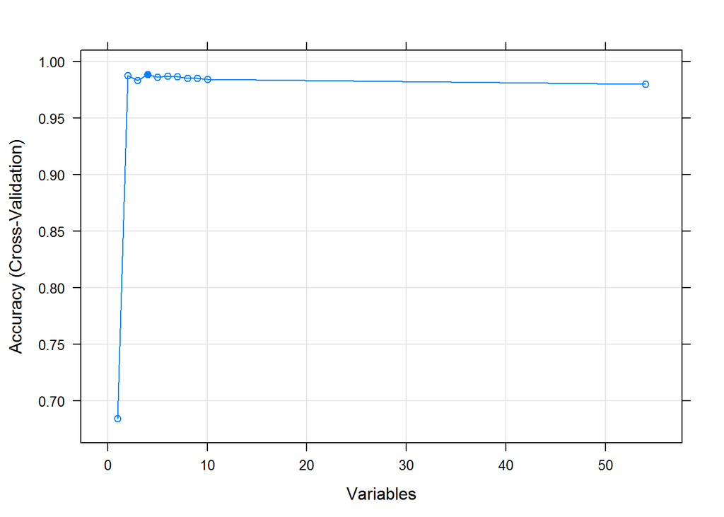

```r
# plot top features
plot(profile_rf, type = c("g", "o"))
```

### Model selection

The fourth step was to select a model. The training set was divided into two new data sets; 60% of the observations were selected for the training set (*train_m*) and the rest of the observations were allocated to the test set (*test_m*). Two algorithms were used for model selection : Random Forest and Boosting. Only the four variables identified during the feature selection process were used to train the two models (roll_belt, num_window, magnet_dumbbell_z, yaw_belt). The K-fold technique was again used for cross validation. Both models and algorithms, using training data (in sample error), showed a great level of accuracy with approx. 0.99. This level of accuracy might not be reflected if the models were to use new observations to make predictions. The Model Evaluation phase was the necessary step to validate the out of Sample error.

```r
# create partition to use for the model selection phase, split training set into
# two new data sets (training and test)
train_index_1 <- createDataPartition(y=train_new$classe,p=0.6,list=FALSE)
train_m       <- train_new[train_index_1,]
test_m        <- train_new[-train_index_1,]

# select only important variables based on feature selection results
train_small <- train_m[,c("roll_belt","num_window","magnet_dumbbell_z","yaw_belt","classe")]
test_small  <- test_m[,c("roll_belt","num_window","magnet_dumbbell_z","yaw_belt","classe")]

# define cross validation technique
train_ctrl  <- trainControl(method="cv", number=10)

# train the model with random forest algorithm
model_rf <- train(classe ~ ., data=train_small, trControl=train_ctrl, preProcess=c("center","scale"), method="rf",prox=TRUE)
# train the model with the boosting algorithm
model_gbm <- train(classe ~ ., data=train_small, trControl=train_ctrl, preProcess=c("center","scale"), method="gbm",verbose=FALSE)
```

### Model evaluation

The fifth step, which was the most important in terms of validating the performance of the model. We used the model built using Random Forest and tested the model against the test set (*test_small*) created during the Model selection phase. We performed some predictions using the test set and analyzed the results using the *confusionMatrix* function in caret. The model showed a high level of accuracy (0.99) with test data (Out of sample error).

```r
# make predictions using random forest algorithm and test data sets
rf_predictions <- predict(model_rf, test_small[,1:4])

# summarize results for random forest through the use of the confusionMatrix
confusionMatrix(rf_predictions, test_small$classe)
```

```
## Confusion Matrix and Statistics
##
##           Reference
## Prediction    A    B    C    D    E
##          A 2230    0    0    0    0
##          B    1 1518    0    0    4
##          C    0    0 1368    1    0
##          D    1    0    0 1285    1
##          E    0    0    0    0 1437
##
## Overall Statistics
##
##                Accuracy : 0.999
##                  95% CI : (0.998, 0.9996)
##     No Information Rate : 0.2845
##     P-Value [Acc > NIR] : < 2.2e-16
##
##                   Kappa : 0.9987
##  Mcnemar's Test P-Value : NA
##
## Statistics by Class:
##
##                      Class: A Class: B Class: C Class: D Class: E
## Sensitivity            0.9991   1.0000   1.0000   0.9992   0.9965
## Specificity            1.0000   0.9992   0.9998   0.9997   1.0000
## Pos Pred Value         1.0000   0.9967   0.9993   0.9984   1.0000
## Neg Pred Value         0.9996   1.0000   1.0000   0.9998   0.9992
## Prevalence             0.2845   0.1935   0.1744   0.1639   0.1838
## Detection Rate         0.2842   0.1935   0.1744   0.1638   0.1832
## Detection Prevalence   0.2842   0.1941   0.1745   0.1640   0.1832
## Balanced Accuracy      0.9996   0.9996   0.9999   0.9995   0.9983
```

### Programming assignment

The model built, it was easy to use it to predict the “classe” variable of the 20 observations (programming assignment).

```r
# this chunck of code is not evaluated
# select the most important variables from the original test data
test_final  <- test_new [,c("roll_belt","num_window","magnet_dumbbell_z","yaw_belt","problem_id")]

# make predictions on the test set, problem_id can only be a number between 1 and 20
ans <- predict(model_rf,test_final[which(test_final$problem_id == 20),-5])
# print output
print(ans)
```